# 02 - Finding the Syncpoint

## Team Members

- Daniel Bruckner

```python
import os

os.chdir('..')

import cv2

import pandas as pd
import numpy as np
import seaborn as sb

from tqdm import tqdm
from skimage import io
from skimage.transform import resize
from matplotlib import pyplot as plt
from evaluate import YoloTest
import plotly.graph_objects as go
import plotly.io as pio
```

Our first tries with the Yolo network proved to return acceptable results on the datasets that represent scenarios commonly occuring in film. It has an accuracy of `0.94` with a Kappa score of `0.876`.

Our first try is to find the points in a movie file at which a film slate switches from open to closed. That point is going to be the sync point. So first, we have to go through the classes and find the points in the file at which the status changes from open to closed.

## Loading Yolo

The Yolo implementation we are using here is an implementation from Github by YunYang1994. We did transfer learning on that implementation using our own labeled images.

```python
yoloTest = YoloTest()
```

```
INFO:tensorflow:Restoring parameters from checkpoint/archive_1/yolov3_test_loss=0.6454.ckpt-20
```

## Load data and Ground truth files

We've assigned every frame of the testing files to a ground truth label and saved those to a csv-file. That way, we can see how accurate our methods for finding syncpoints are.

The first step is to load those files and mark the ground truth sync points to have a way of measuring model performance.

```python
root_path = 'test_video/'
```

The ground truth file has the labels saved as keywords `open` and `closed`. To be able to plot that, we have to assign a numerical label to each keyword:

```python
ground_truth_value = {'open': 1, 'closed': 0}
```

```python
def get_ground_truth_value(row):
    return ground_truth_value[row['class_name']]
```

To maintain the original frame order, we have to extract the frame number and cast it to `int`

```python
def create_number_column(row):
    image_path = row['image_path']
    file_name = image_path.split('/')[-1]
    file_number = file_name.split('.')[0]
    return int(file_number)
```

Load the ground truth data and create a file name number to be able to iterate through the frames in chronologocal order:

```python
def load_ground_truth_file(path):
    gt = pd.read_csv(path)
    del gt['Unnamed: 0']
    gt['file_number'] = gt.apply(create_number_column, axis=1)
    gt = gt.sort_values(by='file_number')
    gt['ground_truth'] = gt.apply(get_ground_truth_value, axis=1)
    return gt
```

```python
def load_all_ground_truth_files(root):
    ground_truth_files = list()

    for file in os.listdir(root):
        if 'csv' in file:
            gt = load_ground_truth_file(os.path.join(root, file))
            ground_truth_files.append(gt)

    return ground_truth_files
```

```python
ground_truths = load_all_ground_truth_files(root_path)
ground_truths[0].head()
```

|  | image_path | class_name | file_number | ground_truth |
| --- | --- | --- | --- | --- |
| 0 | frames_1/open/0.jpg | open | 0 | 1 |
| 1 | frames_1/open/1.jpg | open | 1 | 1 |
| 56 | frames_1/open/2.jpg | open | 2 | 1 |
| 176 | frames_1/closed/3.jpg | closed | 3 | 0 |
| 185 | frames_1/closed/4.jpg | closed | 4 | 0 |

## Ground Truth values

Plot the raw Ground Truths of the second clip:

```python
pio.templates.default = "plotly_white"
```

```python
fig = go.Figure()

fig.add_trace(go.Scatter(y=ground_truths[1]['ground_truth'], mode="lines"))

fig.update_layout(
    title="Ground Truth Slate state",
    xaxis_title="Frame number",
    yaxis_title="Confidence",
)

fig.show()
```

[interactive chart not shown]

Find the state changes from open to closed:

```python
def find_sync_points(slate_states):
    syncpoints = list()
    gt_1 = np.array(slate_states).astype(np.float32).astype(np.int32)

    for i in range(len(gt_1) - 1):
        state_0 = gt_1[i]
        state_1 = gt_1[i + 1]

        if state_0 == 1 and state_1 == 0:
            syncpoints.append(i)

    return syncpoints
```

```python
syncpoints_gt_1 = find_sync_points(ground_truths[1]['ground_truth'])
print("Sync points = {}".format(syncpoints_gt_1))
```

```
Sync points = [21, 117, 752, 1418, 1515, 1569, 1614, 1889, 1929, 1968, 2011, 2050, 2101, 2131, 2178, 2240, 2302, 2344, 2385, 2430, 2478, 2527, 2580, 2746]
```

#### Plot the Ground Truth Sync Points:

```python
fig = go.Figure()

x = np.linspace(0, len(ground_truths[1]['ground_truth']), len(ground_truths[1]['ground_truth'])).astype(np.int32)
y = np.asarray(ground_truths[1]['ground_truth']).astype(np.float32).astype(np.int32)

fig.add_trace(go.Scatter(x=x, y=y, mode="lines", name="Ground Truth"))

fig.add_trace(go.Scatter(x=[x[j] for j in syncpoints_gt_1],
                         y=[y[j] for j in syncpoints_gt_1],
                         mode='markers', name="Ground Truth Sync Points"))

fig.update_layout(
    title="Ground Truth Slate state",
    xaxis_title="Frame number",
    yaxis_title="Confidence",
)

fig.show()
```

[interactive chart not shown]

## Run the classification

```python
def load_frame(frame_path):
    frame = io.imread(frame_path)
    return frame
```

```python
def classify_frames(root, frames):
    confidence_scores = list()
    classes = list()

    for frame_number in tqdm(frames['image_path']):
        frame = load_frame(os.path.join(root, frame_number))
        prediction = yoloTest.predict(frame)

        if len(prediction) > 0:
            confidence_scores.append(prediction[0][4])
            classes.append(prediction[0][5])
        else:
            confidence_scores.append(None)
            classes.append(None)

    return np.array(confidence_scores), np.array(classes)
```

```python
def classify_all_ground_truth_files(root, ground_truth_data):
    confidence_across_all = list()

    for frames in ground_truth_data:
        classification_results = classify_frames(root, frames)
        confidence_across_all.append(classification_results)

    return np.asarray(confidence_across_all)
```

```python
confidences = classify_all_ground_truth_files(root_path, ground_truths)
```

### Find the syncpoints found by the network

Sync points for the first test-film:

```python
film_1_syncpoints = find_sync_points(confidences[0][1])
print("Film 1 Syncpoints = {}".format(film_1_syncpoints))
```

```
Film 1 Syncpoints = [2, 31, 117, 199]
```

Ground Truth:

```python
film_1_ground_truth = find_sync_points(ground_truths[0]['ground_truth'])
print("Film 2 Ground Truth = {}".format(film_1_ground_truth))
```

```
Film 2 Ground Truth = [2, 31, 139, 200, 230]
```

Syncpoints for the second test-film

```python
film_2_syncpoints = find_sync_points(confidences[1][1])
print("Film 2 Syncpoints = {}".format(film_2_syncpoints))
```

```
Film 2 Syncpoints = [20, 64, 91, 96, 117, 653, 659, 712, 752, 811, 837, 841, 1418, 1514, 1568, 1613, 1888, 1968, 2011, 2050, 2100, 2130, 2178, 2225, 2302, 2344, 2385, 2430, 2478, 2526, 2580, 2745]
```

Ground Truth:

```python
film_2_ground_truth = find_sync_points(ground_truths[1]['ground_truth'])
print("Film 2 Ground Truth = {}".format(film_2_ground_truth))
```

```
Film 2 Ground Truth = [21, 117, 752, 1418, 1515, 1569, 1614, 1889, 1929, 1968, 2011, 2050, 2101, 2131, 2178, 2240, 2302, 2344, 2385, 2430, 2478, 2527, 2580, 2746]
```

### Test the performance

To be able to test the performance of our model, we need a metric to measure said performance. If one slating moment wasn't captured by the model, the resulting vector containing the sync points is going to be shorter than the ground truth vector. This makes it harder to use traditional performance metrics like accuracy, precision, recall, etc. So, we will define a percentage metric that tells us the portion ground truth syncpoints correctly predicted.

Sometimes it is not easy to see if a single frame if the slate is open or closed due to slow shutter speeds that blur the clapper. Mostly, even humans can't tell if it is open or closed. This leads to Neural Networks often predicting syncpoints with a one frame offset to the ground truth. The prediction is still on point. Also, a one frame offset is mostly not problematic for video-audio syncing. So, we will leave a one frame tolerance to matches

```python
def syncpoints_match(ground_truth, predicted):
    if ground_truth == predicted:
        return True
    elif (ground_truth - 1) == predicted:
        return True
    elif (ground_truth + 1) == predicted:
        return True
    else:
        return False
```

A metric that measures the portion of correctly identified syncpoints out of the total amount of syncpoints in the ground truth set.

```python
def total_coverage(ground_truths, predictions):
    matches = 0

    for gt_syncpoint in ground_truths:
        for predicted_syncpoint in predictions:
            match = syncpoints_match(ground_truth=gt_syncpoint, predicted=predicted_syncpoint)

            if match:
                matches += 1

    return matches/len(ground_truths)
```

```python
total_coverage_film_1 = total_coverage(film_1_ground_truth, film_1_syncpoints)
total_coverage_film_2 = total_coverage(film_2_ground_truth, film_2_syncpoints)

print("Total Coverage film 1 = {}".format(total_coverage_film_1))
print("Total Coverage film 2 = {}".format(total_coverage_film_2))
```

```
Total Coverage film 1 = 0.6
Total Coverage film 2 = 0.9166666666666666
```

In film #1, 60% of the syncpoints were successfully identified, while in film #2 it was 91,6% meaning that the model can identify the syncpoints better in film #2.

A metric that measures how many of the predicted syncpoints are real syncpoints.

```python
def tpr(ground_truths, predictions):
    matches = 0

    for pred in predictions:
        for gt in ground_truths:
            match = syncpoints_match(ground_truth=gt, predicted=pred)

            if match:
                matches += 1

    return matches / len(predictions)
```

```python
tpr_film_1 = tpr(film_1_ground_truth, film_1_syncpoints)
tpr_film_2 = tpr(film_2_ground_truth, film_2_syncpoints)

print("True Positive Rate film 1 = {}".format(tpr_film_1))
print("True Positive Rate film 2 = {}".format(tpr_film_2))
```

```
True Positive Rate film 1 = 0.75
True Positive Rate film 2 = 0.6875
```

For film #1, three out of the four predicted syncpoints are correct, while the number is lower for film #2. This has something to do with the length of the film and the amount of sync points. More syncpoints and a longer film mean a higher change of false guesses.

To have one metric that combines both the total coverage of ground truth syncpoints and the true positive rate of predicted syncpoints, we calculate the average out of both. This gives us a metric that encompasses both aspects.

```python
def performance_score(ground_truth, predictions):
    true_positive_rate = tpr(ground_truth, predictions)
    coverage = total_coverage(ground_truth, predictions)
    return np.mean([true_positive_rate, coverage])
```

```python
performance_film_1 = performance_score(film_1_ground_truth, film_1_syncpoints)
performance_film_2 = performance_score(film_2_ground_truth, film_2_syncpoints)

print("Performance score on film 1 = {}".format(performance_film_1))
print("Performance score on film 2 = {}".format(performance_film_2))
```

```
Performance score on film 1 = 0.675
Performance score on film 2 = 0.8020833333333333
```

Best possible score:

```python
performance_score(film_2_ground_truth, film_2_ground_truth)
```

```
1.0
```

We can see here that the model performed a lot better on film #2, which can be attributed to the fact that film #2 is more similar to the training data. This means that the model can understand the input images better for this film.

## Plot the discovered syncpoints

```python
fig = go.Figure()

x = np.linspace(0, len(confidences[1][1]), len(confidences[1][1]))
y_pred = np.asarray(confidences[1][1]).astype(np.float32).astype(np.int32)

# Ground Truth
fig.add_trace(go.Scatter(x=x, y=ground_truths[1]['ground_truth'], mode="lines", name="Ground Truth"))
fig.add_trace(go.Scatter(x=[x[j] for j in syncpoints_gt_1],
                         y=[y[j] for j in syncpoints_gt_1],
                         mode='markers', name="Ground Truth Sync Points"))

# Predicted
fig.add_trace(go.Scatter(x=x, y=confidences[1][1], mode="lines", name="Prediction"))
fig.add_trace(go.Scatter(x=[x[j] for j in film_2_syncpoints],
                         y=[y_pred[j] for j in film_2_syncpoints],
                         mode='markers', name="Predicted Sync Points"))
fig.add_trace(go.Scatter(x=x, y=confidences[1][0], mode='lines', name="Confidence"))



fig.update_layout(
    title="Ground Truth Slate state",
    xaxis_title="Frame number",
    yaxis_title="Confidence",
)

fig.show()
```

[interactive chart not shown]

We can see that at some points the model falsely predicts a false syncpoint. What can also be seen is that the confidence drops before and after these false positives. This means that we can factor that in to improve the prediction.

```python
def is_in_list(x, target_list):
    for l in target_list:
        if syncpoints_match(x, l):
            return True

    return False
```

```python
def get_true_positives(ground_truths, predictions, confidences):
    matches = list()
    confs = list()

    for gt_syncpoint in ground_truths:
        for predicted_syncpoint in predictions:
            match = syncpoints_match(ground_truth=gt_syncpoint, predicted=predicted_syncpoint)

            if match:
                matches.append(predicted_syncpoint)
                c_1 = confidences[predicted_syncpoint - 2:predicted_syncpoint]
                c_2 = confidences[predicted_syncpoint:predicted_syncpoint + 2]
                confs.append(np.mean([np.mean(c_1), np.mean(c_2)]))

    return np.array(list(zip(matches, confs, np.ones_like(confs))))
```

```python
def get_false_positives(predictions, true_positives, confidences):
    false_positives = list()
    confs = list()

    for pred in predictions:
        if pred not in true_positives:
            false_positives.append(pred)
            c_1 = confidences[pred - 2:pred]
            c_2 = confidences[pred:pred + 2]
            confs.append(np.mean([np.mean(c_1), np.mean(c_2)]))

    return np.array(list(zip(false_positives, confs, np.zeros_like(confs))))
```

```python
tp_1 = get_true_positives(film_1_ground_truth, film_1_syncpoints, confidences[0][0])
fp_1 = get_false_positives(film_1_syncpoints, tp_1, confidences[0][0])

tp_2 = get_true_positives(film_2_ground_truth, film_2_syncpoints, confidences[1][0])
fp_2 = get_false_positives(film_2_syncpoints, tp_2, confidences[1][0])
```

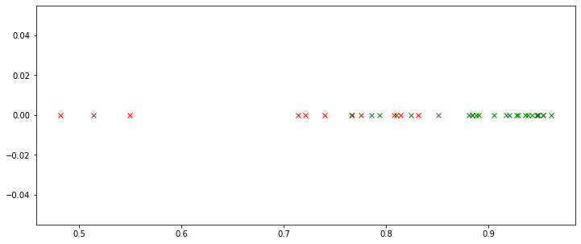

```python
from matplotlib import pyplot as plt

plt.figure(figsize=(12, 5))
val = 0. # this is the value where you want the data to appear on the y-axis.
ar = np.arange(10) # just as an example array

plt.plot(fp_1[:, 1], np.zeros_like(fp_1[:, 1]) + val, 'x', c='r')
plt.plot(tp_1[:, 1], np.zeros_like(tp_1[:, 1]) + val, 'x', c='g')
plt.plot(fp_2[:, 1], np.zeros_like(fp_2[:, 1]) + val, 'x', c='r')
plt.plot(tp_2[:, 1], np.zeros_like(tp_2[:, 1]) + val, 'x', c='g')

plt.show()
```

## Improve method for finding syncpoints

So far, we are only looking at points at which the predicted slate state switches from open to closed. However, this can give us a lot of false positives since it doesn't take into account the confidence values and the sorrounding frames states.

```python
def improved_syncpoint_detection(predicted_states, confidence_values,
                                 confidence_margin, confidence_threshold):

    detected_syncpoints = find_sync_points(predicted_states)
    detected_syncpoints_clean = list()

    confidence_values[np.where(confidence_values == None)] = 0.5

    for p in detected_syncpoints:

        average_confidence_left = np.mean(confidence_values[p - confidence_margin:p])
        average_confidence_right = np.mean(confidence_values[p:p + confidence_margin])
        average_confidence = (average_confidence_left + average_confidence_right) / 2

        if average_confidence >= confidence_threshold:
            detected_syncpoints_clean.append(p)

    return detected_syncpoints_clean
```

Test run with the improved detection method:

```python
film_2_syncpoints_clean = improved_syncpoint_detection(confidences[1][1],
                                                       confidences[1][0], 2, 0.85)

performance_score(ground_truth=film_2_ground_truth, predictions=film_2_syncpoints_clean)
```

```
0.875
```

As we can see, it already improves the score by a significant margin. The prediction itself doesn't get any better. The only thing this algorithm can do is remove false positives from the prediction set. To improve the total coverage, the model has to be improved in various ways (more data, hyperparameter tuning, context information, etc.)

### Grid Search on filtering method to find the best hyperparameters

To find the optimal parameters to filter out false positives, we have to implement a grid search that tries every parameter combination and returns the combination that gives the best results according to our previously defined metric.

```python
from itertools import permutations, product, combinations
from tqdm import tqdm
```

Define hyperparameters to try:

```python
margin = np.linspace(1, 20, 8, dtype=np.int32)
confidence_threshold = [0.7, 0.75, 0.8, 0.85, 0.9, 0.95]
```

Create a list of all combinations

```python
all_combinations = [list(zip(each_permutation, confidence_threshold)) for
                    each_permutation in permutations(margin, len(confidence_threshold))]

all_combinations = np.array(all_combinations)
all_combinations = all_combinations.reshape(all_combinations.shape[0] * all_combinations.shape[1], 2)
```

Perform Grid Search

```python
max_score = 0
best_parameters = None

for combination in tqdm(all_combinations):
    syncpoints = improved_syncpoint_detection(
        predicted_states=confidences[1][1],
        confidence_values=confidences[1][0],
        confidence_margin=int(combination[0]),
        confidence_threshold=combination[1])

    score = performance_score(ground_truth=film_2_ground_truth, predictions=syncpoints)

    if score > max_score:
        max_score = score
        best_parameters = combination
```

```python
print("Best score = {}".format(max_score))
print("Optimal margin = {}".format(best_parameters[0]))
print("Optimal threshold = {}".format(best_parameters[1]))
```

```
Best score = 0.9166666666666667
Optimal margin = 9.0
Optimal threshold = 0.85
```

Get coverage and false positives values:

```python
film_2_syncpoints_clean = improved_syncpoint_detection(confidences[1][1],
                                                       confidences[1][0], 2, 0.85)
```

```python
tpr(film_2_ground_truth, film_2_syncpoints_clean)
```

```
1.0
```

```python
total_coverage(film_2_ground_truth, film_2_syncpoints_clean)
```

```
0.75
```

Overall, the performance of the complete model got better (80% to 91%). No false positives are left over. The filtering algorithm eliminated them all from the predictions set. However, the total coverage went down. The reason for that is that the filter removes low confidence syncpoints. Sync points with a low confidence sorrounding area indicating that the model returned a wrong classification result at that index. To improve that, we need to improve the model itself through various methods including more data and including giving a couple of frames before the clap into the training process to give it more context information.

## *Distance to the closest syncpoint*

*We didn't use the metrics defined here in further notebooks because the resulting numbers aren't meaningful and interpretable enough. However, it might be interesing. So we left this part here*

It always nice to have a second metric to be able to judge model performance more accurately. So far, we have a metric that measures the relative amount of correctly identified sync points. There are a couple of things that this metric doesn't tell us:

- How large is the median frame margin between incorrectly classified syncpoints and ground truth syncpoints

This would give us a way to see if the model was only a couple of frames off or if it didn't understand the problem at all. Also:

- What is the average margin between predicted and ground truth syncpoints
- What is the median margin between predicted and ground truth syncpoints

#### Helper methods

Find the margin between non-matches and their nearest ground truth syncpoints

Check if an element is contained in a list along with the previously defined tolerance threshold:

Get the smallest distance between a value and each array element

```python
def get_delta_with_nearest_syncpoint(x, array):
    array = np.asarray(array)
    nearest_index = (np.abs(array - x)).argmin()
    return np.abs(x - array[nearest_index])
```

#### Average Margin between nearest ground truth points and false detections

Calculate the average margin between the ground truth syncpoints that weren't predicted by the model and their nearest predicted syncpoints:

```python
def get_negative_margins(ground_truths, predictions):
    matches = list()
    non_matches = list()
    margins = list()

    # Get Sync Points matching with Ground Truth

    if len(ground_truths) >= len(predictions):
        for gt_syncpoint in ground_truths:
            for predicted_syncpoint in predictions:
                match = syncpoints_match(ground_truth=gt_syncpoint, predicted=predicted_syncpoint)
                if match:
                    matches.append(predicted_syncpoint)
    else:
        for predicted_syncpoint in predictions:
            for gt_syncpoint in ground_truths:
                match = syncpoints_match(ground_truth=gt_syncpoint, predicted=predicted_syncpoint)
                if match:
                    matches.append(predicted_syncpoint)

    # Get Ground Truth Points not matching with predicted syncpoints
    for gt_syncpoint in ground_truths:
        if not is_in_list(gt_syncpoint, matches):
            non_matches.append(gt_syncpoint)

    # Add up all of the margins to their nearest point in the predictions array
    for non_match in non_matches:
        margins.append(get_delta_with_nearest_syncpoint(non_match, predictions))

    return margins
```

```python
def average_negative_margin(ground_truths, predictions):
    negative_margins = get_negative_margins(ground_truths, predictions)

    if len(negative_margins) > 0:
        return np.mean(negative_margins)
    else:
        return 0
```

If there are several large outliers on the predicted syncpoints data set, the average margin would be distorted. A Median based metric would not be affected by a couple of large margins (outliers). It is useful to see, if there are any large outliers:

```python
def average_negative_margin(ground_truths, predictions):
    negative_margins = get_negative_margins(ground_truths, predictions)

    if len(negative_margins) > 0:
        return np.median(negative_margins)
    else:
        return 0
```

Get the metrics for the two testing films along with the best possble value (feeding the ground truth into the predictions suggesting a perfect match) and a very bad value (random prediction outcomes).

To get a picture of how a completely random model would classify the frames, we have to create 100 random prediction array and calculate the average margin. The reason for that is that the random generations generate a high variance in the margin values.

```python
random_negative_margin_film_1 = 0

for i in range(100):
    random_syncpoints_film_1 = np.random.randint(0, len(confidences[0][1]), len(film_1_syncpoints))
    random_negative_margin_film_1 += average_negative_margin(film_1_ground_truth, random_syncpoints_film_1)

random_negative_margin_film_1 = random_negative_margin_film_1 / 100
```

```python
random_negative_margin_film_2 = 0

for i in range(100):
    random_syncpoints_film_2 = np.random.randint(0, len(confidences[0][1]), len(film_2_syncpoints))
    random_negative_margin_film_2 += average_negative_margin(film_2_ground_truth, random_syncpoints_film_2)

random_negative_margin_film_2 = random_negative_margin_film_2 / 100
```

```python
best_negative_margin = average_negative_margin(film_1_ground_truth, film_1_ground_truth)
```

```python
mean_negative_margin_film_1 = average_negative_margin(film_1_ground_truth, film_1_syncpoints)
mean_negative_margin_film_2 = average_negative_margin(film_2_ground_truth, film_2_syncpoints)
median_negative_margin_film_1 = median_negative_margin(film_1_ground_truth, film_1_syncpoints)
median_negative_margin_film_2 = median_negative_margin(film_2_ground_truth, film_2_syncpoints)

print("Average Negative margin Film 1 = {}".format(mean_negative_margin_film_1))
print("Average Negative margin Film 2 = {}".format(mean_negative_margin_film_2))
print("Median Negative margin Film 1 = {}".format(median_negative_margin_film_1))
print("Median Negative margin Film 2 = {}".format(median_negative_margin_film_2))
print("-"*100)
print("Best possible value = {}".format(best_negative_margin))
print("Random values for film 1 = {}".format(random_negative_margin_film_1))
print("Random values for film 2 = {}".format(random_negative_margin_film_2))
```

```
Average Negative margin Film 1 = 26.5
Average Negative margin Film 2 = 27.0
Median Negative margin Film 1 = 26.5
Median Negative margin Film 2 = 27.0
----------------------------------------------------------------------------------------------------
Best possible value = 0
Random values for film 1 = 51.915
Random values for film 2 = 1916.2
```

Looking at the numbers, we can say that the model performed way better on film 2 than it did on film 1. This can be confirmed by the accuracy scores.

#### Average margin between nearest points of ground truth and prediction

As a second performance measure, we define the mean and median distance between the nearest points in prediction and ground truth. The optimal value would be zero, which would mean that every sync point was found with frame level accuracy. Also, we have to scale the values by dividing them through the number of frames to be able to compare the results with one another.

```python
def average_margin_to_nearest_point(ground_truth, predictions, number_of_frames):
    deltas = []

    if len(ground_truth) >= len(predictions):
        for point in ground_truth:
            delta = get_delta_with_nearest_syncpoint(point, predictions)
            deltas.append(delta)
    else:
        for point in predictions:
            delta = get_delta_with_nearest_syncpoint(point, ground_truth)
            deltas.append(delta)

    return np.mean(deltas)/number_of_frames, np.median(deltas)/number_of_frames, deltas
```

Generating random values for comparison:

```python
random_point_margin_film_1 = 0

for i in range(100):
    random_syncpoints_film_1 = np.random.randint(0, len(confidences[0][1]), len(film_1_syncpoints))
    mean, median, _ = average_margin_to_nearest_point(film_1_ground_truth,
                                                random_syncpoints_film_1,
                                                len(confidences[0][1]))
    random_point_margin_film_1 += mean


random_point_margin_film_1 = random_point_margin_film_1 / 100
print("A very bad result = {}".format(random_point_margin_film_1))
```

```
A very bad result = 0.13746613545816738
```

```python
random_point_margin_film_2 = 0

for i in range(100):
    random_syncpoints_film_2 = np.random.randint(0, len(confidences[0][1]), len(film_2_syncpoints))
    mean, median, _ = average_margin_to_nearest_point(film_2_ground_truth,
                                                random_syncpoints_film_2,
                                                len(confidences[0][1]))
    random_point_margin_film_2 += mean


random_point_margin_film_2 = random_point_margin_film_2 / 100
random_point_margin_film_2
```

```
0.18346115537848603
```

Metrics for film #1

```python
mean_point_margin_film_1, median_point_margin_film_1, _ = average_margin_to_nearest_point(film_1_ground_truth,
                                                                                       film_1_syncpoints,
                                                                                         len(confidences[0][1]))

print("Mean Point Margin = {}".format(mean_point_margin_film_1))
print("Median Point Margin = {}".format(median_point_margin_film_1))
```

```
Mean Point Margin = 0.04302788844621514
Median Point Margin = 0.00398406374501992
```

Metrics for film #2

```python
mean_point_margin_film_2, median_point_margin_film_2, _ = average_margin_to_nearest_point(film_2_ground_truth,
                                                                                       film_2_syncpoints,
                                                                                         len(confidences[1][1]))

print("Mean Point Margin = {}".format(mean_point_margin_film_2))
print("Median Point Margin = {}".format(median_point_margin_film_2))
```

```
Mean Point Margin = 0.006404867256637168
Median Point Margin = 0.00035398230088495576
```

### Verdict

We won't use the resulting metrics. The resulting numbers are different for every video we test it on. Consistency is an issue. Also, none of these numbers tell us if the result is good or bad (like i.e. 0.9 is a good accuracy).